# R Notebook

Load necessary packages. **mmir** and **toolbox** are custom packages available from https://github.com/zsmith27.

```r
library(tidyverse)
library(mmir)
library(toolbox)
```

Import the data provided by Kyle Hodgson of MDDNR. To be consistant with MDDNR, rows in the `excluded` represented by “y” are removed from the data set. Only the columns `siteyr`, `taxon`, and `n_taxa` are retained. The data is grouped by `siteyr` and `taxon`. Subsequently, the `n_taxa` is summed across these groups in an attempt to remove a taxon represented more than once in a single sample. Although this was a good check, this does not appear to have been necessary.

```r
dnr.df <- data.table::fread("Muddy Creek Benthic 2014-2017.csv") %>%
  toolbox::prep_df() %>%
  filter(exclude != "y") %>%
  select(siteyr, taxon, n_taxa) %>%
  group_by(siteyr, taxon) %>%
  summarize(count = sum(n_taxa)) %>%
  ungroup() %>%
  rename(unique_id = "siteyr",
         final_id = "taxon")
```

```r
dnr.df <- dnr.df %>%
  mutate(final_id = case_when(
    final_id == "neoporous" ~ "neoporus",
    final_id == "thienemannimyia_group" ~ "thienemannimyia",
    final_id == "tubificidae" ~ "naididae",
    final_id == "girardia" ~ "platyhelminthes",
    TRUE ~ final_id
  ))
```

Import the taxonomic hierarchy and attributes table available from **mmir**.

```r
data("hier.fwmi")
data("attributes.fwmi")
```

Join the taxonomic hierarchy with the MDDNR taxonomic counts.

```r
dnr.df <- left_join(dnr.df, hier.fwmi, by = "final_id")
```

Check for taxa not found in the taxonomic hierarchy table (`hier.fwmi`).

```r
check.df <- dnr.df %>%
  filter(is.na(phylum)) %>%
  select(final_id) %>%
  distinct()
```

Apply the taxonomic standards of the 2017 Chessie BIBI refinement https://www.potomacriver.org/focus-areas/aquatic-life/chessie-bibi-stream-health-indicator/.

```r
dnr.df <- dnr.df %>%
  filter(
    phylum %in% c("annelida", "arthropoda", "mollusca", "platyhelminthes"),
    subphylum %in% c("clitellata", "crustacea", "hexapoda", "rhabditophora") | is.na(subphylum),
    !class %in% c("branchiopoda", "maxillopoda", "ostracoda"),
    !order %in% c("hymenoptera"),
    !family %in% c("gerridae", "hebridae", "veliidae", "hydrometridae",
                   "saldidae"),
    !genus %in% c("stenus")
  )

class.spp <- c("class", "subclass", "order", "suborder",
               "family", "subfamily", "tribe", "genus", "species")
dnr.df[dnr.df$class %in% "bivalvia", class.spp] <- "bivalvia"
dnr.df[dnr.df$class %in% "gastropoda", class.spp] <- "gastropoda"
dnr.df[dnr.df$class %in% "oligochaeta", class.spp] <- "oligochaeta"
dnr.df[dnr.df$class %in% "trepaxonemata", class.spp] <- "trepaxonemata"
#============================================================================
# These taxa were not consitently identified to the same taxonomic rank
# by the agencies that contributed data. Therefore, the samples were rolled
# up to the lowest common denominator.
# These columns will be influenced by the common denominator taxa.
order.spp <- c("order", "suborder", "family", "subfamily",
               "tribe", "genus", "species")
dnr.df[dnr.df$order %in% "collembola", order.spp] <- "collembola"
dnr.df[dnr.df$order %in% "lepidoptera", order.spp] <- "lepidoptera"
dnr.df[dnr.df$order %in% "neuroptera", order.spp] <- "neuroptera"
dnr.df[dnr.df$order %in% "neoophora", order.spp] <- "neoophora"

dnr.df <- dnr.df %>%
  group_by_at(vars(-count)) %>%
  summarize(count = sum(count)) %>%
  ungroup() %>%
  fill_taxa(final_id, phylum:species)
```

Summarize taxonomic counts at the family-level.

```r
fam.df <- dnr.df %>%
  select(-subfamily:-species) %>%
  mutate(final_id = family) %>%
  group_by_at(vars(-count)) %>%
  summarize(count = sum(count)) %>%
  left_join(attributes.fwmi, by = "final_id") %>%
  ungroup() %>%
  prob_rarefaction(unique_id, count, family, 100)
```

Summarize taxonomic counts at the genus-level.

```r
gen.df <- dnr.df %>%
  select(-species) %>%
  mutate(final_id = genus) %>%
  group_by_at(vars(-count)) %>%
  summarize(count = sum(count)) %>%
  left_join(attributes.fwmi, by = "final_id") %>%
  ungroup() %>%
  prob_rarefaction(unique_id, count, genus, 100)
```

Make sure all samples have at least 90% of individuals identified at the genus level.

```r
check.gen.pct <- gen.df %>%
  group_by(unique_id) %>%
  mutate(total = sum(count)) %>%
  ungroup() %>%
  group_by(unique_id, genus, total) %>%
  summarize(count = sum(count)) %>%
  mutate(percent = count / total * 100) %>%
  filter(genus == "unidentified",
         percent > 10)
```

Create a function to run all of the necessary metrics for the coastal indices.

```r
# long.df <- fam.df
# taxa.rank <- rlang::quo(family)
run_metrics <- function(long.df, taxa.rank) {
  taxa.rank <- enquo(taxa.rank)
  rare.df <- long.df %>%
    filter(rare_count > 0)

  final.df <- long.df %>%
    select(unique_id) %>%
    distinct() %>%
    mutate(
      GOLD = 100 - (
        taxa_pct(
          long.df,
          unique_id,
          count,
          class,
          c("gastropoda", "oligochaeta")
        ) +
          taxa_pct(long.df, unique_id, count, order, "diptera")
      ),
      MARGALEFS = taxa_div(rare.df,
                           unique_id,
                           rare_count,
                           high.taxa.col = !!taxa.rank,
                           job = "margalef"),
      PCT_EPT_RICH = taxa_pct_rich(
        rare.df,
        unique_id,
        order,
        taxon = c("ephemeroptera", "plecoptera", "trichoptera"),!!taxa.rank
      ),
      RICH_EPHEMEROPTERA = taxa_rich(
        rare.df,
        unique_id,
        rare_count,
        order,
        "ephemeroptera",
        !!taxa.rank
      ),
      PCT_COLLECT = taxa_pct(long.df, unique_id, count, bibi_ffg, c("cg", "cf")),
      PCT_PREDATOR = taxa_pct(long.df, unique_id, count, bibi_ffg, "pr"),
      RICH_FILTER = taxa_rich(rare.df, unique_id, rare_count, bibi_ffg, "cf",!!taxa.rank),
      RICH_CLIMB = taxa_rich(rare.df, unique_id, rare_count, bibi_habit, "cb",!!taxa.rank),
      ASPT_MOD = taxa_tol_index(rare.df, unique_id, count, aspt),
      HBI = taxa_tol_index(long.df, unique_id, count, bibi_tv),
      PCT_EPT_NO_HYDRO = if_else(
        taxa_pct(long.df, unique_id, count, family, "hydropsychidae") == 0,
        0,
        100 * (1 - (
          taxa_pct(long.df, unique_id, count, family, "hydropsychidae") /
            taxa_pct(
              long.df,
              unique_id,
              count,
              order,
              c("ephemeroptera", "plecoptera", "trichoptera")
            )
        ))
      ),
      PCT_DIPTERA = taxa_pct(long.df, unique_id, count, order, "diptera"),
      HURLBERTS_PIE = taxa_div(rare.df,
                               unique_id,
                               rare_count,
                               high.taxa.col = !!taxa.rank,
                               job = "gini_simpson"),
      PCT_GATHER = taxa_pct(long.df, unique_id, count, bibi_ffg, "cg"),
      PCT_BURROW = taxa_pct(long.df, unique_id, count, bibi_habit, "bu"),
      RICH_BURROW = taxa_rich(rare.df, unique_id, rare_count, bibi_habit, "bu", !!taxa.rank),
      PCT_DOM1 = taxa_dom(long.df, unique_id, count, !!taxa.rank, 1),
      PCT_TOLERANT_5_10 = taxa_pct(long.df, unique_id, count, bibi_tv, 5:10),
      PCT_TOLERANT_7_10 = taxa_pct(long.df, unique_id, count, bibi_tv, 7:10),
      RICH_TOL = taxa_rich(rare.df, unique_id, rare_count, bibi_tv, 7:10, !!taxa.rank),
      PCT_COTE = taxa_pct(
        long.df,
        unique_id,
        count,
        order,
        c("coleoptera", "odonata",
          "trichoptera", "ephemeroptera")
      ),
      PCT_EPT_RICH_NO_TOL = taxa_pct_rich(
        rare.df,
        unique_id,
        # rare_count,
        order,
        taxon = c("ephemeroptera", "plecoptera", "trichoptera"),
        !!taxa.rank,
        exclusion.col = bibi_tv,
        exclusion.vec = 7:10
      ),
      RICH_TRICHOPTERA = taxa_rich(
        rare.df,
        unique_id,
        rare_count,
        order,
        "trichoptera",
        !!taxa.rank
      ),
      RICH_COLLECT = taxa_rich(
        rare.df,
        unique_id,
        rare_count,
        bibi_ffg,
        c("cg", "cf"),
        !!taxa.rank
      ),
      PCT_CLING = taxa_pct(long.df, unique_id, count, bibi_habit, "cn"),
      RICH_CLING = taxa_rich(rare.df, unique_id, rare_count, bibi_habit, "cn",!!taxa.rank),
      PCT_OLIGO_CHIRO = taxa_pct(long.df, unique_id, count, class, "oligochaeta") +
        taxa_pct(long.df, unique_id, count, family, "chironomidae"),
      RICH_PREDATOR = taxa_rich(rare.df, unique_id, rare_count, bibi_ffg, "pr",!!taxa.rank),
      PCT_MOD_TOL_4_6 = taxa_pct(long.df, unique_id, count, bibi_tv, 4:6)
    )
  if ("genus" %in% names(long.df)) {
    final.df <- final.df %>%
      mutate(PCT_CAECIDOTEA = taxa_pct(long.df, unique_id, count, genus, "caecidotea"))
  }
  final.df <- final.df %>%
    clean_df()
  return(final.df)
}
```

Calculate all of the metrics at the family- and genus-level.

```r
metrics.fam <- run_metrics(fam.df, family) %>%
  gather(metric, value, gold:pct_mod_tol_4_6)
metrics.gen <- run_metrics(gen.df, genus) %>%
  gather(metric, value, gold:pct_caecidotea)
```

Import the metric scoring thresholds from the 2017 Chessie BIBI refinment.

```r
score.thresh <- data.table::fread("H:/Projects/Chessie_BIBI/report/FINAL_May25_2017/2017_Data/Metric_Thresholds/metric_thresholds.csv") %>%
  clean_df() %>%
  rowwise() %>%
  mutate(upper = max(ref_median, bound),
         lower = min(ref_median, bound)) %>%
  ungroup()
```

A function to join the metric values with the scoring thresholds for the appropriate taxonomic level and spatial level.

```r
# taxa.res <- "family"
# spatial.res <- "coast"
# metrics.df <- metrics.gen
#
# thresh.df <- score.thresh

join_metric_thresh <- function(metrics.df, thresh.df, taxa.res, spatial.res) {
  score.sub <- thresh.df %>%
  filter(taxonomic_resolution == taxa.res,
         spatial_resolution == spatial.res)

final.df <- inner_join(metrics.df, score.sub, by = "metric")

scores.vec <- score.sub[!score.sub$metric %in% unique(final.df$metric), "metric"]
if (nrow(scores.vec) > 0) warning(paste("warning: The following metrics are missing:", scores.vec$metric))
return(final.df)
}
```

Apply the `join_metri_thesh()` function.

```r
fam.coast <- join_metric_thresh(metrics.fam, score.thresh, "family", "coast")
gen.coast <- join_metric_thresh(metrics.gen, score.thresh, "genus", "coast")
fam.sep <- join_metric_thresh(metrics.fam, score.thresh, "family", "sep")
gen.sep <- join_metric_thresh(metrics.gen, score.thresh, "genus", "sep")
metrics.df <- bind_rows(fam.coast, gen.coast, fam.sep, gen.sep)
```

Scoring functions to apply the scoring thresholds to the raw metric values.

```r
dec_func <- function(upper, lower, value) {
  dplyr::case_when(
    value <= lower ~ 0,
    value >= upper ~ 100,
    value < upper &
    value > lower ~ ((value - lower) / (upper - lower)) * 100,
    TRUE ~ 100000
  )
}
inc_func <- function(upper, lower, value) {
  dplyr::case_when(
    value <= lower ~ 100,
    value >= upper ~ 0,
    value < upper &
      value > lower ~ ((upper - value) / (upper - lower)) * 100,
    TRUE ~ 100000
  )
}

score_func <- function(long.df, upper.thresh.col, lower.thresh.col, value.col) {
  value.col <- rlang::enquo(value.col)
  upper.thresh.col <- rlang::enquo(upper.thresh.col)
  lower.thresh.col <- rlang::enquo(lower.thresh.col)

  final.df <- long.df %>%
    dplyr::mutate(score = case_when(
      influence_of_disturbance == "decrease" ~ dec_func(rlang::UQ(upper.thresh.col),
                                                        rlang::UQ(lower.thresh.col),
                                                        rlang::UQ(value.col)),
      influence_of_disturbance == "increase" ~ inc_func(rlang::UQ(upper.thresh.col),
                                                        rlang::UQ(lower.thresh.col),
                                                        rlang::UQ(value.col)),
      TRUE ~ -100000))

  return(final.df)
}
```

Establish a standard output path.

```r
output.path <- file.path("D:/ZSmith/Projects/Chessie_BIBI/BIBI/R",
                       "bibi/notebook/sections/misc/mbss_hodgson_2018_08/output")
```

Score the raw metric values.

```r
scores.df <- score_func(metrics.df, upper, lower, value)
file.name <- file.path(output.path,
                       paste("bibi_metrics_", Sys.Date(), ".csv"))
data.table::fwrite(scores.df, file.name)
```

Calculate the IBI scores by finding the mean metric score for each sampling event.

```r
ibi.df <- scores.df %>%
  group_by(unique_id, spatial_resolution, taxonomic_resolution) %>%
  summarize(score = mean(score)) %>%
  ungroup()
```

Import the rating thresholds for each taxonomic resolution and spatial resolution.

```r
rating.thresh <- data.table::fread("H:/Projects/Chessie_BIBI/report/FINAL_May25_2017/2017_Data/Rating_Thresholds/rating_threshold_06292017.csv", data.table = FALSE)
```

Place the index scores into coarse rating bins and export the table.

```r
rating.df <- left_join(ibi.df, rating.thresh, by = c("spatial_resolution", "taxonomic_resolution")) %>%
  mutate(rating = case_when(
    score < half_ref_10 ~ "very_poor",
    score >= half_ref_10 & score < ref_10 ~ "poor",
    score >= ref_10 & score < ref_25 ~ "fair",
    score >= ref_25 & score < ref_50 ~ "good",
    score >= ref_50 ~ "excellent",
    TRUE ~ "ERROR"
  )) %>%
  select(-half_ref_10:-ref_50) %>%
  mutate(resolution = paste(spatial_resolution, taxonomic_resolution, sep = "_")) %>%
  select(-spatial_resolution, -taxonomic_resolution) %>%
  arrange(resolution)

file.name <- file.path(output.path, paste0("bibi_scores_", Sys.Date(), ".csv"))
data.table::fwrite(rating.df, file.name)
```

Compare the ratings from each index with stacked barplots.

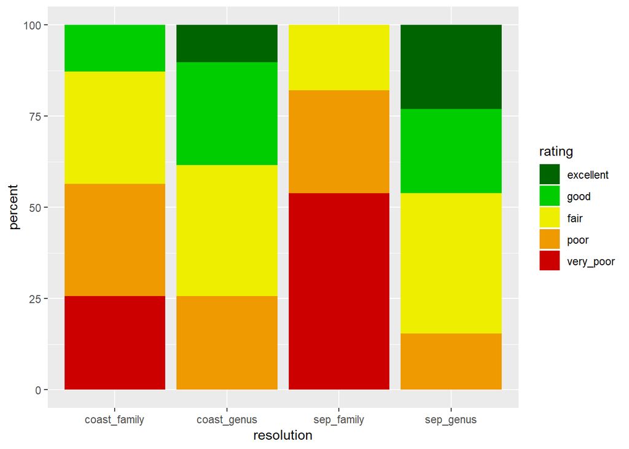

```r
test <- rating.df %>%
  group_by(resolution) %>%
  mutate(total = n()) %>%
  group_by(resolution, rating, total) %>%
  summarize(count = n()) %>%
  ungroup() %>%
  mutate(percent = count / total * 100,
         rating = factor(rating, levels = c("excellent", "good", "fair",
                                            "poor", "very_poor"))) %>%
  arrange(resolution, rating)

g.plot <- ggplot(test) +
  geom_bar(aes(y = percent, x = resolution, fill = rating), data = test,
                           stat="identity") +
  scale_fill_manual(name = "rating",
                    labels = c("excellent", "good", "fair", "poor", "very_poor"),
                    values = c("excellent" = "darkgreen",
                               "good" = "green3",
                               "fair" = "yellow2",
                               "poor" = "orange2",
                               "very_poor" = "red3"))
g.plot
```

```r
file.name <- file.path(output.path, paste0("bibi_stacked_", Sys.Date(), ".png"))
ggsave(file.name, g.plot)
```